# Source memory performance for objects inside the rooms

# 1 Visual inspection of the data

# 2 Novelty Benefits

## 2.1 Check the data

**Is there any corrected hit rate < 0?**

There are 3 negative value out of a total of 80 participants.

```
##    SubjectNo    Group MeanCurRt MeanDur     SFHit      SHit     SrcHit
## 1:       P16 Familiar  3.666667     NaN 0.3888889 0.2222222 0.00000000
## 2:       P34 Familiar  2.666667     NaN 0.7222222 0.4444444 0.16666667
## 3:       P39 Familiar  4.000000     NaN 0.9444444 0.6111111 0.05555556
##       SFFalse    SFalse   SrcFalse      SFAcc      SAcc      SrcAcc
## 1: 0.05555556 0.0000000 0.01851852 0.33333333 0.2222222 -0.01851852
## 2: 0.66666667 0.3333333 0.22222222 0.05555556 0.1111111 -0.05555556
## 3: 0.22222222 0.0000000 0.07407407 0.72222222 0.6111111 -0.01851852
```

## 2.2 Compare mean accuracy between *novel* and *familiar* rooms

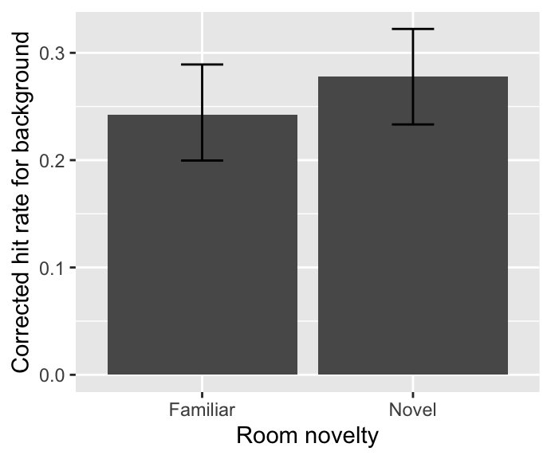

Figure1. Mean accuracy for item memory respectively for Familiar and Novel rooms.

```
##       Group      Mean        SD  N
## 1: Familiar 0.2419799 0.1378855 40
## 2:    Novel 0.2778199 0.1411349 40
```

```
##
##  Paired t-test
##
## data:  SrcAcc by Group
## t = -1.2902, df = 39, p-value = 0.2046
## alternative hypothesis: true difference in means is not equal to 0
## 95 percent confidence interval:
##  -0.09202767  0.02034778
## sample estimates:
## mean of the differences
##             -0.03583995
```

## 2.3 Any difference between *Early* and *Later* object groups?

**Is there any corrected hit rate < 0?**

There are 9 negative values out of a total of 160 participants.

```
##    SubjectNo    Group ObjOrdGrp MeanCurRt  MeanDur     SFHit      SHit
## 1:       P16 Familiar     Early  3.666667      NaN 0.4444444 0.3333333
## 2:       P16 Familiar     Later  3.666667      NaN 0.3333333 0.1111111
## 3:       P30    Novel     Early  4.625000      NaN 0.2500000 0.2500000
## 4:       P34 Familiar     Early  2.666667      NaN 0.6666667 0.4444444
## 5:       P39 Familiar     Early  4.000000      NaN 0.8888889 0.7777778
## 6:       P40    Novel     Later  5.333333      NaN 0.8888889 0.4444444
## 7:       P44    Novel     Later  6.333333 58.17242 0.8888889 0.5555556
## 8:       P52    Novel     Early  5.500000      NaN 1.0000000 1.0000000
## 9:       P52 Familiar     Later  1.500000 84.19194 1.0000000 0.6666667
##       SrcHit    SFFalse     SFalse   SrcFalse       SFAcc      SAcc
## 1: 0.0000000 0.05555556 0.00000000 0.01851852  0.38888889 0.3333333
## 2: 0.0000000 0.05555556 0.00000000 0.01851852  0.27777778 0.1111111
## 3: 0.0000000 0.31818182 0.13636364 0.09090909 -0.06818182 0.1136364
## 4: 0.1111111 0.66666667 0.33333333 0.22222222  0.00000000 0.1111111
## 5: 0.0000000 0.22222222 0.00000000 0.07407407  0.66666667 0.7777778
## 6: 0.0000000 0.05555556 0.00000000 0.01851852  0.83333333 0.4444444
## 7: 0.1111111 0.38888889 0.05555556 0.12962963  0.50000000 0.5000000
## 8: 0.0000000 0.23333333 0.00000000 0.07777778  0.76666667 1.0000000
## 9: 0.0000000 0.23333333 0.00000000 0.07777778  0.76666667 0.6666667
##         SrcAcc
## 1: -0.01851852
## 2: -0.01851852
## 3: -0.09090909
## 4: -0.11111111
## 5: -0.07407407
## 6: -0.01851852
## 7: -0.01851852
## 8: -0.07777778
## 9: -0.07777778
```

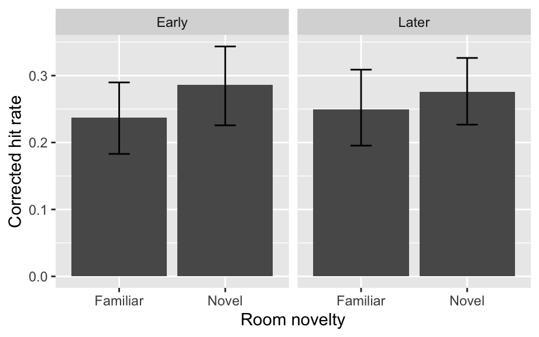

```
##       Group ObjOrdGrp      Mean        SD  N
## 1: Familiar     Early 0.2371188 0.1655807 40
## 2:    Novel     Early 0.2862434 0.1968643 40
## 3:    Novel     Later 0.2760077 0.1681957 40
## 4: Familiar     Later 0.2497114 0.1870154 40
```

```
## $ANOVA
##            Effect DFn DFd           F         p p<.05          ges
## 2           Group   1  39 1.883018601 0.1778330       1.114278e-02
## 3       ObjOrdGrp   1  39 0.002453646 0.9607463       1.100411e-05
## 4 Group:ObjOrdGrp   1  39 0.161834079 0.6896700       1.031276e-03
```

# 3 Curiosity Enhancement

## 3.1 Check the data

### 3.1.1 Is there any corrected hit rate < 0?

#### 3.1.1.1 For the data per room

- There are 27 negative values out of a total of 236 values.

```
##     SubjectNo     Context    Group CurRating RoomOrder  Duration     SFHit
##  1:       P13     Library    Novel         6     First        NA 0.8333333
##  2:       P15     Bedroom Familiar         4     First        NA 0.6666667
##  3:       P16     Bedroom Familiar         4     First        NA 0.5000000
##  4:       P16   Classroom Familiar         2     First        NA 0.1666667
##  5:       P16         Gym Familiar         5    Second        NA 0.5000000
##  6:       P20     Library    Novel         2     First        NA 0.8333333
##  7:       P23   Classroom    Novel         5     First        NA 0.6666667
##  8:       P30     Library    Novel         4     First        NA 0.5000000
##  9:       P30  LivingRoom    Novel         5     First        NA 0.5000000
## 10:       P32   Classroom    Novel         7    Second        NA 0.8333333
## 11:       P32         Gym    Novel         5     First        NA 1.0000000
## 12:       P33         Gym Familiar         1    Second        NA 0.3333333
## 13:       P33  LivingRoom    Novel         6    Second        NA 0.8333333
## 14:       P34     Bedroom Familiar         3    Second        NA 0.5000000
```

[output cut: 72 more lines]

#### 3.1.1.2 For the data per curiosity group

- There are 3 negative value for curiosity group (1 ~ 3 and 5 ~ 7) out of a total of 76 values.

```
##    SubjectNo CurGrp MeanDur     SFHit      SHit    SrcHit    SFFalse
## 1:       P16    Low     NaN 0.1666667 0.1666667 0.0000000 0.05555556
## 2:       P34    Low     NaN 0.7222222 0.4444444 0.1666667 0.66666667
## 3:       P39    Low     NaN 1.0000000 0.6666667 0.0000000 0.22222222
##       SFalse   SrcFalse      SFAcc      SAcc      SrcAcc
## 1: 0.0000000 0.01851852 0.11111111 0.1666667 -0.01851852
## 2: 0.3333333 0.22222222 0.05555556 0.1111111 -0.05555556
## 3: 0.0000000 0.07407407 0.77777778 0.6666667 -0.07407407
```

#### 3.1.1.3 For the data per curiosity group (median)

- There are 3 negative value for curiosity group (median) out of a total of 79 values.

```
##    SubjectNo CurGrpMedian MeanDur     SFHit      SHit    SrcHit    SFFalse
## 1:       P16          Low     NaN 0.3888889 0.2222222 0.0000000 0.05555556
## 2:       P34          Low     NaN 0.7222222 0.4444444 0.1666667 0.66666667
## 3:       P39          Low     NaN 0.9166667 0.5833333 0.0000000 0.22222222
##       SFalse   SrcFalse      SFAcc      SAcc      SrcAcc
## 1: 0.0000000 0.01851852 0.33333333 0.2222222 -0.01851852
## 2: 0.3333333 0.22222222 0.05555556 0.1111111 -0.05555556
## 3: 0.0000000 0.07407407 0.69444444 0.5833333 -0.07407407
```

## 3.2 Mean accuracy of item memory as a function of curiosity rating

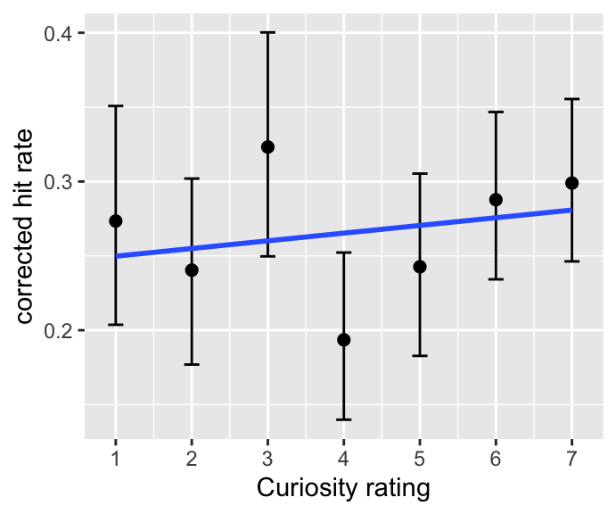

## 3.3 Testing the relationship between mean accuracy of item memory and curiosity rating

Build models with item memory accuracy as $y$ and examine effects of curiosity rating by including it into the model and then comparing the model fits.

- `baseline.rating` is the model with only an intercept, showing no change in item memory as a function of curiosity rating.
- `rating.intercept` is the model with $\small CuriosityRating$ included, showing the effects of curiosity rating.
- `rating.slope` is the model allowing the slope (i.e., relationship between item memory and curiosity rating) varying across participants.

```
##                  Model df       AIC        BIC   logLik   Test  L.Ratio
## baseline.rating      1  3 -117.7058 -107.31426 61.85288
## rating.intercept     2  4 -116.9480 -103.09265 62.47399 1 vs 2 1.242218
## rating.slope         3  6 -114.9746  -94.19161 63.48730 2 vs 3 2.026623
##                  p-value
## baseline.rating
## rating.intercept   0.265
## rating.slope       0.363
```

## 3.4 Check the curiosity groups

### 3.4.1 Separate the groups according to the rating

- *High*: curiosity rating > 4
- *Low*: curiosity rating < 4
- For curiosity rating = 4, discarded

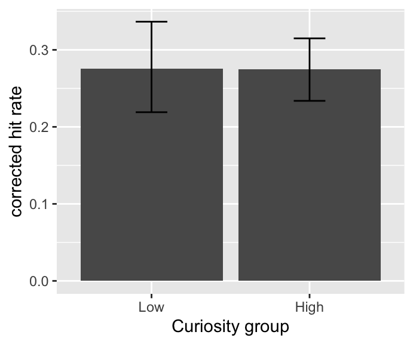

```
##    CurGrp      Mean        SD  N
## 1:   High 0.2748734 0.1359168 40
## 2:    Low 0.2753785 0.1826012 36
```

```
## Linear mixed-effects model fit by maximum likelihood
##  Data: inside.hit.rate.curiosity.group
##         AIC       BIC  logLik
##   -56.81319 -42.82879 34.4066
##
## Random effects:
##  Formula: ~1 + CurGrp | SubjectNo
##  Structure: General positive-definite, Log-Cholesky parametrization
##             StdDev     Corr
## (Intercept) 0.16521198 (Intr)
## CurGrpHigh  0.18709544 -0.8
## Residual    0.07178784
##
## Fixed effects: SrcAcc ~ CurGrp
##                  Value  Std.Error DF  t-value p-value
## (Intercept) 0.27383225 0.03040819 39 9.005213  0.0000
## CurGrpHigh  0.00104118 0.03542498 35 0.029391  0.9767
##  Correlation:
##            (Intr)
## CurGrpHigh -0.797
##
## Standardized Within-Group Residuals:
##         Min          Q1         Med          Q3         Max
## -0.95414482 -0.37939290 -0.00987595  0.32168788  1.16228423
##
## Number of Observations: 76
## Number of Groups: 40
```

#### 3.4.1.1 Curiosity groups and temporal order of the objects

##### 3.4.1.1.1 Check the data

- **Is there any corrected hit rate < 0?**
  - There are 12 negative values out of a total of 152 values.

```
##     SubjectNo CurGrp ObjOrdGrp     SFHit      SHit     SrcHit    SFFalse
##  1:       P16    Low     Early 0.3333333 0.3333333 0.00000000 0.05555556
##  2:       P16    Low     Later 0.0000000 0.0000000 0.00000000 0.05555556
##  3:       P19    Low     Later 0.5000000 0.5000000 0.00000000 0.16666667
##  4:       P20    Low     Later 1.0000000 1.0000000 0.00000000 0.22222222
##  5:       P23   High     Early 0.7500000 0.6666667 0.08333333 0.33333333
##  6:       P34    Low     Early 0.6666667 0.4444444 0.11111111 0.66666667
##  7:       P39    Low     Early 1.0000000 1.0000000 0.00000000 0.22222222
##  8:       P39    Low     Later 1.0000000 0.3333333 0.00000000 0.22222222
##  9:       P40   High     Later 0.8888889 0.4444444 0.00000000 0.05555556
## 10:       P44   High     Later 0.8888889 0.5555556 0.11111111 0.38888889
## 11:       P52   High     Early 1.0000000 1.0000000 0.00000000 0.23333333
## 12:       P52    Low     Later 1.0000000 0.6666667 0.00000000 0.23333333
##         SFalse   SrcFalse       SFAcc      SAcc       SrcAcc
##  1: 0.00000000 0.01851852  0.27777778 0.3333333 -0.018518519
##  2: 0.00000000 0.01851852 -0.05555556 0.0000000 -0.018518519
##  3: 0.05555556 0.05555556  0.33333333 0.4444444 -0.055555556
##  4: 0.22222222 0.07407407  0.77777778 0.7777778 -0.074074074
##  5: 0.11111111 0.09259259  0.41666667 0.5555556 -0.009259259
##  6: 0.33333333 0.22222222  0.00000000 0.1111111 -0.111111111
##  7: 0.00000000 0.07407407  0.77777778 1.0000000 -0.074074074
##  8: 0.00000000 0.07407407  0.77777778 0.3333333 -0.074074074
##  9: 0.00000000 0.01851852  0.83333333 0.4444444 -0.018518519
## 10: 0.05555556 0.12962963  0.50000000 0.5000000 -0.018518519
## 11: 0.00000000 0.07777778  0.76666667 1.0000000 -0.077777778
## 12: 0.00000000 0.07777778  0.76666667 0.6666667 -0.077777778
```

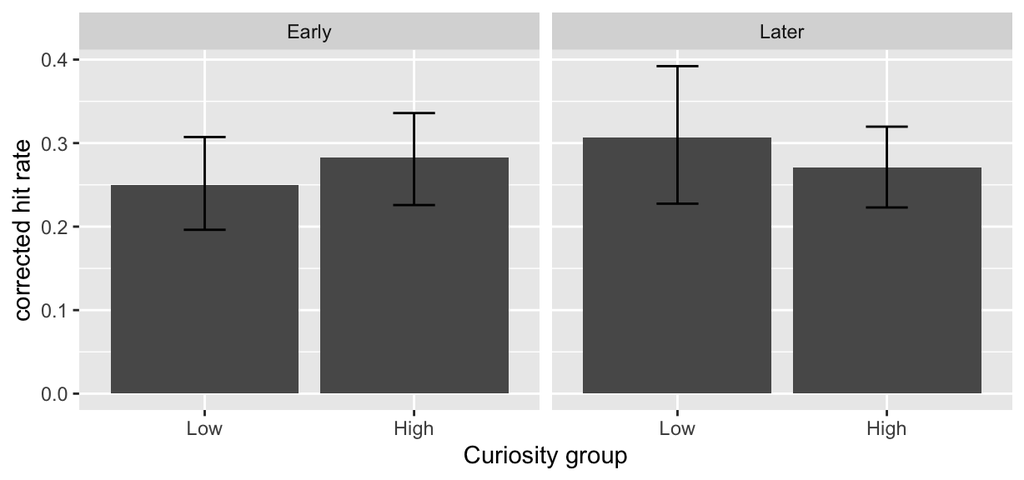

```
##    CurGrp ObjOrdGrp      Mean        SD  N
## 1:   High     Early 0.2824976 0.1838495 40
## 2:   High     Later 0.2707299 0.1575671 40
## 3:    Low     Later 0.3062169 0.2574313 36
## 4:    Low     Early 0.2503013 0.1775944 36
```

```
##           Model df       AIC       BIC   logLik   Test   L.Ratio p-value
## baseline      1  8 -65.84588 -41.65483 40.92294
## ord.model     2  9 -64.39972 -37.18479 41.19986 1 vs 2 0.5538399  0.4568
## cur.model     3 10 -62.47797 -32.23916 41.23898 2 vs 3 0.0782501  0.7797
## int.model     4 11 -62.53414 -29.27146 42.26707 3 vs 4 2.0561765  0.1516
```

```
## Linear mixed-effects model fit by maximum likelihood
##  Data: inside.hit.rate.item.order.curiosity[!is.na(CurGrp)]
##         AIC       BIC   logLik
##   -62.53414 -29.27146 42.26707
##
## Random effects:
##  Formula: ~1 + CurGrp + ObjOrdGrp | SubjectNo
##  Structure: General positive-definite, Log-Cholesky parametrization
##                StdDev     Corr
## (Intercept)    0.11231305 (Intr) CrGrpH
## CurGrpHigh     0.15559512 -0.672
## ObjOrdGrpLater 0.09358547  0.531 -0.976
## Residual       0.14839760
##
## Fixed effects: SrcAcc ~ ObjOrdGrp + CurGrp + ObjOrdGrp:CurGrp
##                                 Value  Std.Error  DF   t-value p-value
## (Intercept)                0.24798051 0.03136390 109  7.906560  0.0000
## ObjOrdGrpLater             0.05836455 0.03873194 109  1.506884  0.1347
## CurGrpHigh                 0.03451709 0.04297494 109  0.803191  0.4236
## ObjOrdGrpLater:CurGrpHigh -0.07013222 0.04905243 109 -1.429740  0.1557
##  Correlation:
##                           (Intr) ObjOGL CrGrpH
## ObjOrdGrpLater            -0.386
## CurGrpHigh                -0.713  0.149
## ObjOrdGrpLater:CurGrpHigh  0.398 -0.671 -0.559
##
## Standardized Within-Group Residuals:
##         Min          Q1         Med          Q3         Max
## -1.93377562 -0.58245838 -0.05756146  0.59762084  2.24506025
##
## Number of Observations: 152
## Number of Groups: 40
```

##### 3.4.1.1.2 *Post hoc*

```
##
##   Simultaneous Tests for General Linear Hypotheses
##
## Fit: lme.formula(fixed = SrcAcc ~ ObjOrdGrp + CurGrp + ObjOrdGrp:CurGrp,
##     data = inside.hit.rate.item.order.curiosity[!is.na(CurGrp)],
##     random = ~1 + CurGrp + ObjOrdGrp | SubjectNo, method = "ML",
##     na.action = na.exclude, control = list(msMaxIter = 500, opt = "optim",
##         msVerbose = FALSE))
##
## Linear Hypotheses:
##                          Estimate Std. Error z value Pr(>|z|)
## Early: High vs. Low == 0  0.03452    0.04241   0.814    0.416
## Late:  High vs. Low == 0 -0.03562    0.04298  -0.829    0.407
## (Adjusted p values reported -- none method)
```

### 3.4.2 Separate the groups according to the median rating of each participant

- *High*: curiosity rating > median of the participant
- *Low*: curiosity rating < median of the participant

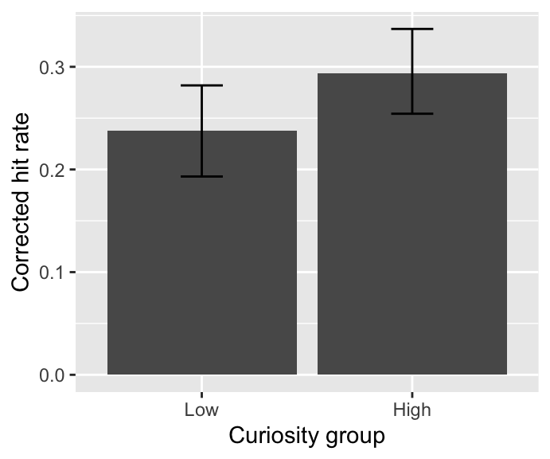

```
## Linear mixed-effects model fit by maximum likelihood
##  Data: inside.hit.rate.curiosity.group.median
##         AIC       BIC   logLik
##   -74.91972 -60.70304 43.45986
##
## Random effects:
##  Formula: ~1 + CurGrpMedian | SubjectNo
##  Structure: General positive-definite, Log-Cholesky parametrization
##                  StdDev    Corr
## (Intercept)      0.1287438 (Intr)
## CurGrpMedianHigh 0.1648217 -0.681
## Residual         0.0624029
##
## Fixed effects: SrcAcc ~ CurGrpMedian
##                       Value  Std.Error DF   t-value p-value
## (Intercept)      0.23781325 0.02291329 39 10.378833  0.0000
## CurGrpMedianHigh 0.05533726 0.03014534 38  1.835682  0.0742
##  Correlation:
##                  (Intr)
## CurGrpMedianHigh -0.681
##
## Standardized Within-Group Residuals:
##         Min          Q1         Med          Q3         Max
## -0.87029486 -0.37806962  0.03158885  0.28182972  1.21938511
##
## Number of Observations: 79
## Number of Groups: 40
```

#### 3.4.2.1 Curiosity groups and temporal order of the objects

##### 3.4.2.1.1 Check the data

- **Is there any corrected hit rate < 0?**
  - There are 12 negative values out of a total of 158 participants.

```
##     SubjectNo CurGrpMedian ObjOrdGrp     SFHit      SHit    SrcHit
##  1:       P16          Low     Early 0.4444444 0.3333333 0.0000000
##  2:       P16          Low     Later 0.3333333 0.1111111 0.0000000
##  3:       P20          Low     Later 1.0000000 1.0000000 0.0000000
##  4:       P23          Low     Later 0.7777778 0.6666667 0.0000000
##  5:       P30          Low     Early 0.5000000 0.3333333 0.0000000
##  6:       P34          Low     Early 0.6666667 0.4444444 0.1111111
##  7:       P39          Low     Later 1.0000000 0.5000000 0.0000000
##  8:       P39          Low     Early 0.8333333 0.6666667 0.0000000
##  9:       P40         High     Later 0.8888889 0.4444444 0.0000000
## 10:       P44         High     Later 0.8888889 0.5555556 0.1111111
## 11:       P52         High     Early 1.0000000 1.0000000 0.0000000
## 12:       P52          Low     Later 1.0000000 0.6666667 0.0000000
##        SFFalse     SFalse   SrcFalse     SFAcc      SAcc      SrcAcc
##  1: 0.05555556 0.00000000 0.01851852 0.3888889 0.3333333 -0.01851852
##  2: 0.05555556 0.00000000 0.01851852 0.2777778 0.1111111 -0.01851852
##  3: 0.22222222 0.22222222 0.07407407 0.7777778 0.7777778 -0.07407407
##  4: 0.33333333 0.11111111 0.09259259 0.4444444 0.5555556 -0.09259259
##  5: 0.31818182 0.13636364 0.09090909 0.1818182 0.1969697 -0.09090909
##  6: 0.66666667 0.33333333 0.22222222 0.0000000 0.1111111 -0.11111111
##  7: 0.22222222 0.00000000 0.07407407 0.7777778 0.5000000 -0.07407407
##  8: 0.22222222 0.00000000 0.07407407 0.6111111 0.6666667 -0.07407407
##  9: 0.05555556 0.00000000 0.01851852 0.8333333 0.4444444 -0.01851852
## 10: 0.38888889 0.05555556 0.12962963 0.5000000 0.5000000 -0.01851852
## 11: 0.23333333 0.00000000 0.07777778 0.7666667 1.0000000 -0.07777778
## 12: 0.23333333 0.00000000 0.07777778 0.7666667 0.6666667 -0.07777778
```

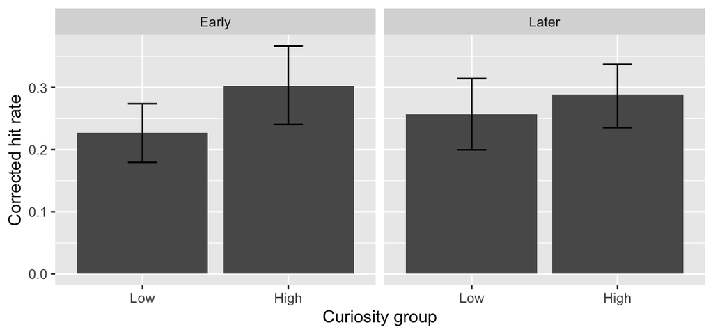

```
##    CurGrpMedian ObjOrdGrp      Mean        SD  N
## 1:          Low     Early 0.2268915 0.1626324 40
## 2:         High     Early 0.3021300 0.2047500 39
## 3:         High     Later 0.2882648 0.1638115 39
## 4:          Low     Later 0.2571188 0.1968406 40
```

```
##           Model df       AIC       BIC   logLik   Test   L.Ratio p-value
## baseline      1  8 -78.45030 -53.94954 47.22515
## ord.model     2  9 -76.96400 -49.40064 47.48200 1 vs 2 0.5137024  0.4735
## cur.model     3 10 -78.03754 -47.41159 49.01877 2 vs 3 3.0735408  0.0796
## int.model     4 11 -76.85265 -43.16410 49.42633 3 vs 4 0.8151113  0.3666
```

```
## Linear mixed-effects model fit by maximum likelihood
##  Data: inside.hit.rate.item.order.curiosity.median[!is.na(CurGrpMedian)]
##         AIC       BIC   logLik
##   -78.03754 -47.41159 49.01877
##
## Random effects:
##  Formula: ~1 + CurGrpMedian + ObjOrdGrp | SubjectNo
##  Structure: General positive-definite, Log-Cholesky parametrization
##                  StdDev     Corr
## (Intercept)      0.05922180 (Intr) CrGrMH
## CurGrpMedianHigh 0.10826797 -0.333
## ObjOrdGrpLater   0.08421954  0.507 -0.958
## Residual         0.15428012
##
## Fixed effects: SrcAcc ~ ObjOrdGrp + CurGrpMedian
##                       Value  Std.Error  DF   t-value p-value
## (Intercept)      0.23784098 0.02337555 116 10.174776  0.0000
## ObjOrdGrpLater   0.00832838 0.02820918 116  0.295236  0.7683
## CurGrpMedianHigh 0.05258355 0.03028466 116  1.736310  0.0852
##  Correlation:
##                  (Intr) ObjOGL
## ObjOrdGrpLater   -0.369
## CurGrpMedianHigh -0.505 -0.262
##
## Standardized Within-Group Residuals:
##         Min          Q1         Med          Q3         Max
## -1.98723026 -0.59694991 -0.04310974  0.61608652  2.15167268
##
## Number of Observations: 158
## Number of Groups: 40
```

##### 3.4.2.1.2 *Post hoc*

```
##
##   Simultaneous Tests for General Linear Hypotheses
##
## Fit: lme.formula(fixed = SrcAcc ~ ObjOrdGrp + CurGrpMedian + ObjOrdGrp:CurGrpMedian,
##     data = inside.hit.rate.item.order.curiosity.median[!is.na(CurGrpMedian)],
##     random = ~1 + CurGrpMedian + ObjOrdGrp | SubjectNo, method = "ML",
##     na.action = na.exclude, control = list(msMaxIter = 500, opt = "optim",
##         msVerbose = FALSE))
##
## Linear Hypotheses:
##                          Estimate Std. Error z value Pr(>|z|)
## Early: High vs. Low == 0  0.07484    0.03866   1.936   0.0529 .
## Late:  High vs. Low == 0  0.03040    0.03862   0.787   0.4312
## ---
## Signif. codes:  0 '***' 0.001 '**' 0.01 '*' 0.05 '.' 0.1 ' ' 1
## (Adjusted p values reported -- none method)
```

# 4 **Novelty** or **Curiosity**?

## 4.1 For Curiosity group splitted by score (*Low*: 1 ~ 3; *High*: 5 ~ 7)

### 4.1.1 Curiosity first, novelty next

```
##               Model df       AIC       BIC   logLik   Test  L.Ratio
## base.model        1  8 -90.80491 -64.14316 53.40246
## cur.scr.model     2  9 -88.81416 -58.81969 53.40708 1 vs 2 0.009250
## nov.scr.model     3 10 -90.13573 -56.80855 55.06787 2 vs 3 3.321572
##               p-value
## base.model
## cur.scr.model  0.9234
## nov.scr.model  0.0684
```

```
## Linear mixed-effects model fit by maximum likelihood
##  Data: inside.hit.rate.per.room[!is.na(CurGrp)]
##         AIC       BIC   logLik
##   -88.81416 -58.81969 53.40708
##
## Random effects:
##  Formula: ~1 + CurGrp + Group | SubjectNo
##  Structure: General positive-definite, Log-Cholesky parametrization
##             StdDev     Corr
## (Intercept) 0.05492724 (Intr) CrGrpL
## CurGrpLow   0.10396204 -0.313
## GroupNovel  0.07296765  0.089  0.268
## Residual    0.16679601
##
## Fixed effects: SrcAcc ~ CurGrp
##                  Value  Std.Error  DF   t-value p-value
## (Intercept) 0.27049807 0.02035901 166 13.286406  0.0000
## CurGrpLow   0.00303132 0.03030682 166  0.100021  0.9204
##  Correlation:
##           (Intr)
## CurGrpLow -0.544
##
## Standardized Within-Group Residuals:
##         Min          Q1         Med          Q3         Max
## -1.74102207 -0.75332192 -0.01366193  0.67825475  3.42942998
##
## Number of Observations: 207
## Number of Groups: 40
```

### 4.1.2 Novelty first, curiosity next

```
##               Model df       AIC       BIC   logLik   Test  L.Ratio
## base.model        1  8 -90.80491 -64.14316 53.40246
## nov.scr.model     2  9 -90.10547 -60.11100 54.05274 1 vs 2 1.300561
## cur.scr.model     3 10 -90.13573 -56.80855 55.06787 2 vs 3 2.030262
##               p-value
## base.model
## nov.scr.model  0.2541
## cur.scr.model  0.1542
```

```
## Linear mixed-effects model fit by maximum likelihood
##  Data: inside.hit.rate.per.room[!is.na(CurGrp)]
##         AIC     BIC   logLik
##   -90.10547 -60.111 54.05274
##
## Random effects:
##  Formula: ~1 + CurGrp + Group | SubjectNo
##  Structure: General positive-definite, Log-Cholesky parametrization
##             StdDev     Corr
## (Intercept) 0.05365514 (Intr) CrGrpL
## CurGrpLow   0.11663044 -0.436
## GroupNovel  0.05363647  0.534  0.319
## Residual    0.16601549
##
## Fixed effects: SrcAcc ~ Group
##                  Value  Std.Error  DF  t-value p-value
## (Intercept) 0.25490414 0.02235196 166 11.40411  0.0000
## GroupNovel  0.03267571 0.02789934 166  1.17120  0.2432
##  Correlation:
##            (Intr)
## GroupNovel -0.641
##
## Standardized Within-Group Residuals:
##         Min          Q1         Med          Q3         Max
## -1.81988964 -0.74412633  0.01911359  0.63310408  3.39966597
##
## Number of Observations: 207
## Number of Groups: 40
```

## 4.2 For Curiosity group splitted by individual medians

### 4.2.1 Curiosity first, novelty next

```
##              Model df       AIC       BIC   logLik   Test   L.Ratio
## base.model       1  8 -106.5630 -79.16337 61.28148
## cur.md.model     2  9 -107.5289 -76.70436 62.76445 1 vs 2 2.9659385
## nov.md.model     3 10 -105.6974 -71.44789 62.84870 2 vs 3 0.1684831
##              p-value
## base.model
## cur.md.model  0.0850
## nov.md.model  0.6815
```

```
## Linear mixed-effects model fit by maximum likelihood
##  Data: inside.hit.rate.per.room[!is.na(CurGrpMedian)]
##         AIC       BIC   logLik
##   -107.5289 -76.70436 62.76445
##
## Random effects:
##  Formula: ~1 + CurGrpMedian + Group | SubjectNo
##  Structure: General positive-definite, Log-Cholesky parametrization
##                 StdDev     Corr
## (Intercept)     0.06407987 (Intr) CrGrML
## CurGrpMedianLow 0.09800975 -0.374
## GroupNovel      0.03412970  0.777 -0.333
## Residual        0.16389463
##
## Fixed effects: SrcAcc ~ CurGrpMedian
##                       Value  Std.Error  DF   t-value p-value
## (Intercept)      0.29563087 0.02128397 186 13.889836  0.0000
## CurGrpMedianLow -0.05002164 0.02827720 186 -1.768975  0.0785
##  Correlation:
##                 (Intr)
## CurGrpMedianLow -0.649
##
## Standardized Within-Group Residuals:
##         Min          Q1         Med          Q3         Max
## -1.73416091 -0.71047109  0.02950796  0.61416531  3.41695612
##
## Number of Observations: 227
## Number of Groups: 40
```

### 4.2.2 Novelty first, curiosity next

```
##              Model df       AIC       BIC   logLik   Test  L.Ratio p-value
## base.model       1  8 -106.5630 -79.16337 61.28148
## nov.md.model     2  9 -106.2214 -75.39681 62.11068 1 vs 2 1.658391  0.1978
## cur.md.model     3 10 -105.6974 -71.44789 62.84870 2 vs 3 1.476030  0.2244
```

```
## Linear mixed-effects model fit by maximum likelihood
##  Data: inside.hit.rate.per.room[!is.na(CurGrpMedian)]
##         AIC       BIC   logLik
##   -106.2214 -75.39681 62.11068
##
## Random effects:
##  Formula: ~1 + CurGrpMedian + Group | SubjectNo
##  Structure: General positive-definite, Log-Cholesky parametrization
##                 StdDev     Corr
## (Intercept)     0.05941164 (Intr) CrGrML
## CurGrpMedianLow 0.13155716 -0.750
## GroupNovel      0.06523330  0.129  0.488
## Residual        0.16360767
##
## Fixed effects: SrcAcc ~ Group
##                  Value  Std.Error  DF   t-value p-value
## (Intercept) 0.25344377 0.02079817 186 12.185867  0.0000
## GroupNovel  0.03761659 0.02763777 186  1.361057  0.1751
##  Correlation:
##            (Intr)
## GroupNovel -0.633
##
## Standardized Within-Group Residuals:
##         Min          Q1         Med          Q3         Max
## -1.76425173 -0.68889864  0.01357841  0.62207507  3.43453501
##
## Number of Observations: 227
## Number of Groups: 40
```